# MODELOS LINEARES GENERALIZADOS (EST082)

## Seleção

**Código**

```r
n<-nrow(morgan)
numFrac<-expostos-mortos
modelo<-cbind(mortos, numFrac) ~ dose + concentracao + dose:concentracao

binom<-rbind(
ResultadosBinom(morgan, modelo, ligacao = "logit", tipo ="envel_bino_logit"),
ResultadosBinom(morgan, modelo, ligacao = "cauchit", tipo ="envel_bino_cauchit"),
ResultadosBinom(morgan, modelo, ligacao = "probit", tipo ="envel_bino_probit"),
ResultadosBinom(morgan, modelo, ligacao = "cloglog", tipo ="envel_bino_cloglog")
)
```

```
[1] "Binomial-Link(logit)"
```

```
[1] "Binomial-Link(cauchit)"
```

```
[1] "Binomial-Link(probit)"
```

```
[1] "Binomial-Link(cloglog)"
```

**Código**

```
[1] "Binomial-Link(logit)"
```

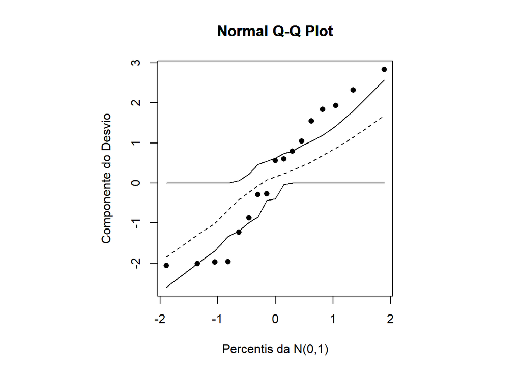

```
[1] "Binomial-Link(cauchit)"
```

```
[1] "Binomial-Link(probit)"
```

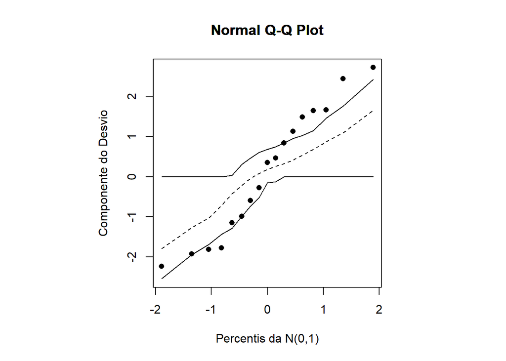

```
[1] "Binomial-Link(cloglog)"
```

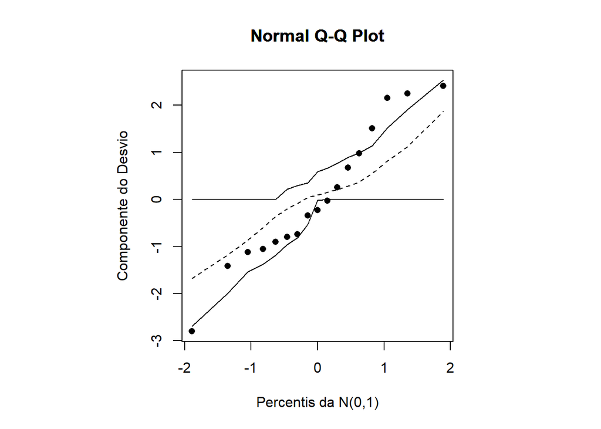

```r
binom2<-rbind(
ResultadosBinom(morgan, modelo, ligacao = "logit", tipo ="envel_bino_logit",step="JAQ"),
ResultadosBinom(morgan, modelo, ligacao = "cauchit", tipo ="envel_bino_cauchit",step="JAQ"),
ResultadosBinom(morgan, modelo, ligacao = "probit", tipo ="envel_bino_probit",step="JAQ"),
ResultadosBinom(morgan, modelo, ligacao = "cloglog", tipo ="envel_bino_cloglog",step="JAQ")
)
```

**Código**

```r
binom |>
  arrange(BIC, desc=T) |>
  knitr::kable(caption = "Melhor modelo - stepAIC", format ="pipe")
```

Melhor modelo - stepAIC

| Family | QQplot | BIC | Modelo |
| --- | --- | --- | --- |
| Binomial-Link(cloglog) | Não Rodou | 92.07089 | cbind(mortos, numFrac) ~ dose + concentracao + dose:concentracao |
| Binomial-Link(probit) | Não Rodou | 96.11790 | cbind(mortos, numFrac) ~ dose + concentracao + dose:concentracao |
| Binomial-Link(logit) | Não Rodou | 98.70616 | cbind(mortos, numFrac) ~ dose + concentracao + dose:concentracao |
| Binomial-Link(cauchit) | Não Rodou | 115.14166 | cbind(mortos, numFrac) ~ dose + concentracao + dose:concentracao |

**Código**

```r
binom2 |>
  arrange(BIC, desc=T) |>
  knitr::kable(caption = "Melhor modelo - stepJAQ", format ="pipe")
```

Melhor modelo - stepJAQ

| Family | QQplot | BIC | Modelo |
| --- | --- | --- | --- |
| Binomial-Link(cloglog) | Ruim | 96.11953 | cbind(mortos, numFrac) ~ dose + concentracao |
| Binomial-Link(probit) | Ruim | 100.60453 | cbind(mortos, numFrac) ~ dose + concentracao |
| Binomial-Link(logit) | Ruim | 102.28794 | cbind(mortos, numFrac) ~ dose + concentracao |
| Binomial-Link(cauchit) | Não Rodou | 115.28120 | cbind(mortos, numFrac) ~ dose + concentracao |

O modelo com o menor BIC foi o cbind(mortos, numFrac) ~ dose + concentracao + dose:concentracao com ligação **cloglog**.

## Teste de adequação da função de ligação

**Código**

```r
modelo<- cbind(mortos, numFrac) ~ dose + concentracao + dose:concentracao
fit.model <- glm(modelo  , family=binomial(link=cloglog))
pl2 <- predict(fit.model)^2
fit.model2<-glm(update.formula(modelo,~ . + pl2), family=binomial(link=cloglog))
testef(fit.model,fit.model2) # fit.model(H0: pl2 não significativa) #H1: pl2 é significativa
```

```
$f
[1] 0.001187865

$df1
[1] 1

$df2
[1] 10

$pvalue
[1] 0.9731843
```

Não temos evidências para rejeitar a hipótese nula, ou seja, a função de ligação cloglog é adequada.

## Resíduos e Diagnóstico

**Código**

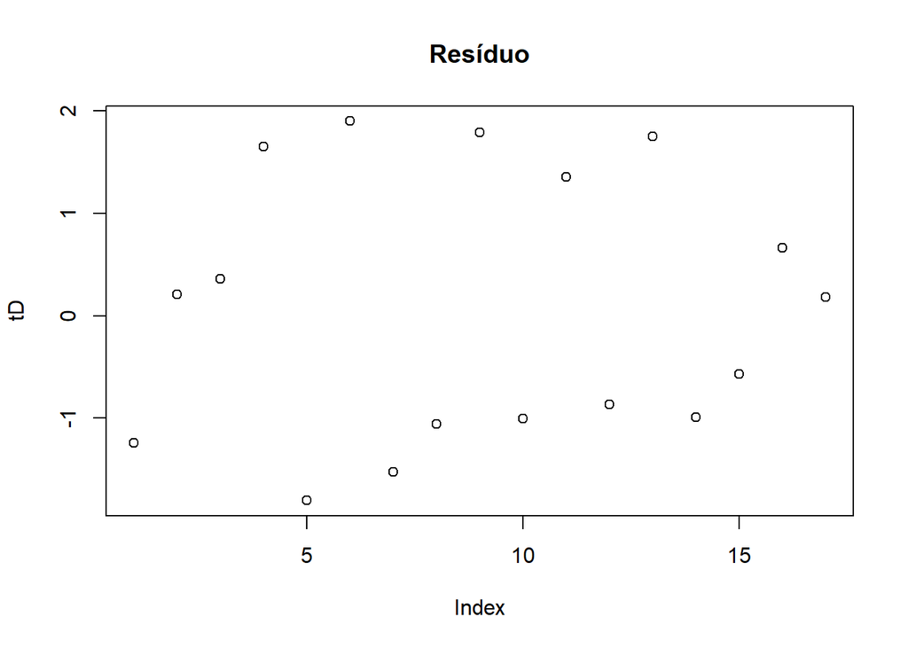

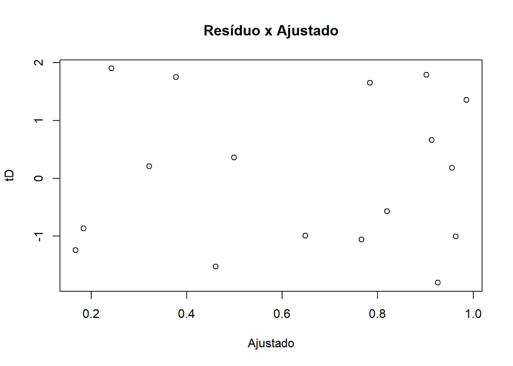

```r
modelo<-cbind(mortos, numFrac) ~ dose + concentracao + dose:concentracao
fit.model <- glm(modelo  , family=binomial(link="cloglog"))

resul.resd<-residuos(fit.model)
```

**Código**

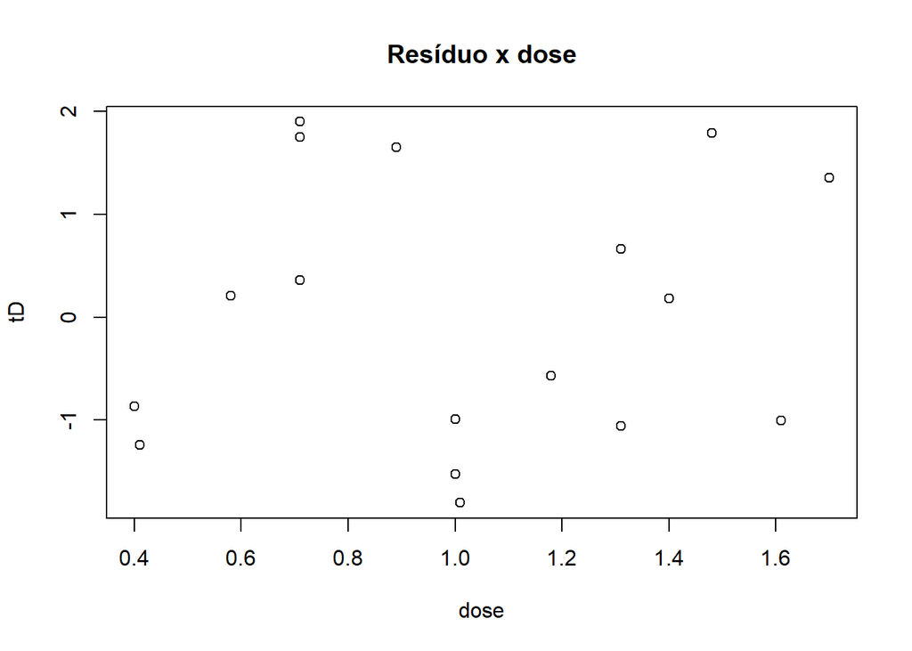

```r
plot(resul.resd$tD~dose, ylab="tD" , main="Resíduo x dose")
```

Não parece haver nenhum padrão. Podemos seguir para o dignóstico.

**Código**

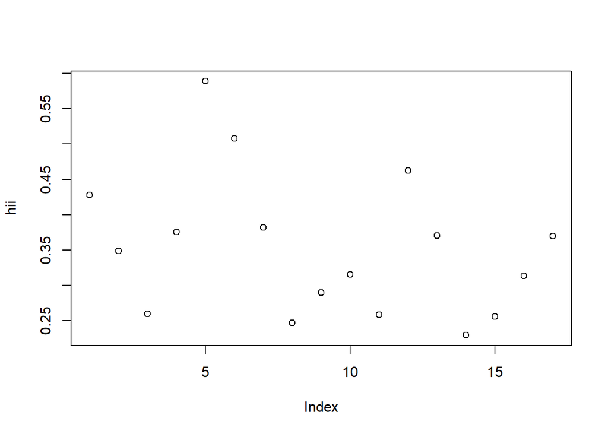

```r
plot(resul.resd$hii, ylab="hii")
```

Não há pontos de alavanca.

**Código**

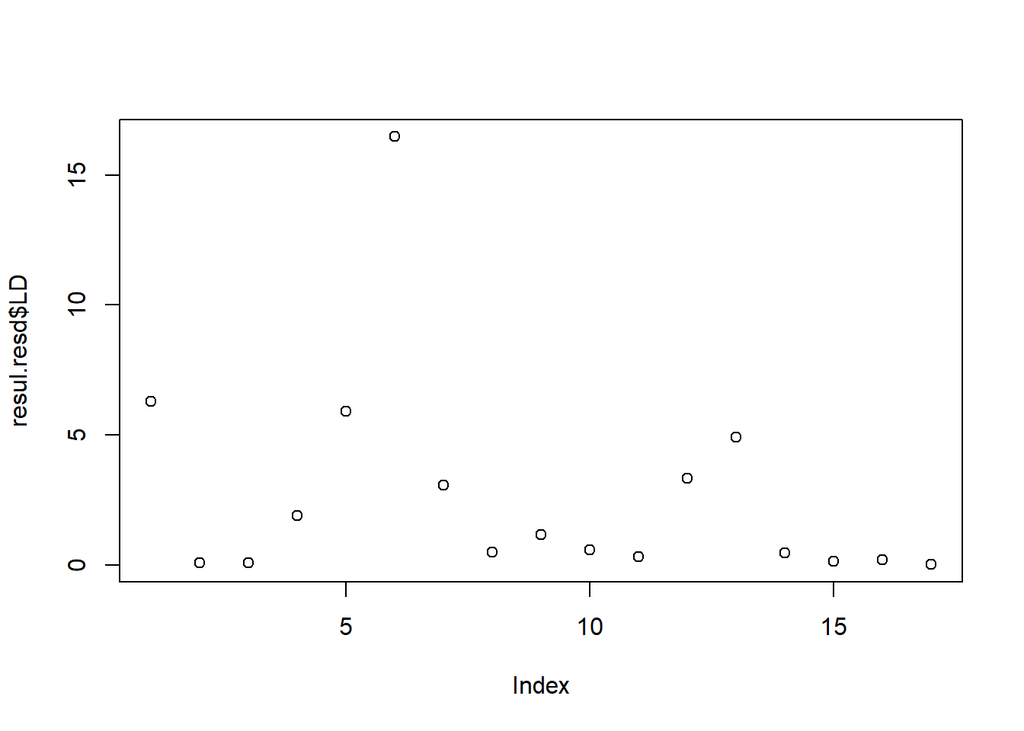

```r
plot(resul.resd$LD)
```

A observação 6 parece influente.

**Código**

```r
morgan[6,]
```

```
# A tibble: 1 × 4
  concentracao  dose expostos mortos
  <fct>        <dbl>    <dbl>  <dbl>
1 D             0.71       49     16
```

**Código**

```r
summary(dose)
```

```
   Min. 1st Qu.  Median    Mean 3rd Qu.    Max.
  0.400   0.710   1.000   1.024   1.310   1.700
```

**Código**

```r
summary(mortos)
```

```
   Min. 1st Qu.  Median    Mean 3rd Qu.    Max.
      6      18      34      31      44      48
```

A observação em questão está no primeiro quartil das variáveis resposta e dose.

# 19.

**Código**

```r
suppressMessages(gestantes <- read_table("dados/lista3/gestantes.txt",
    col_names = FALSE))
colnames(gestantes)<-c("idade","n_cigarro","duracao","morte","sobrev")
gestantes$idade<-factor(gestantes$idade,levels = c(0,1),labels=c("<30","30+"))
gestantes$duracao<-factor(gestantes$duracao,levels = c(0,1),labels=c("<=260",">260"))
gestantes$n_cigarro<-factor(gestantes$n_cigarro,levels = c(0,1),labels=c("<5","5+"))

gestantes<-gestantes |>
  mutate(prop=morte/(morte+sobrev))
suppressMessages(attach(gestantes))
```

## Análise Exploratória

**Código**

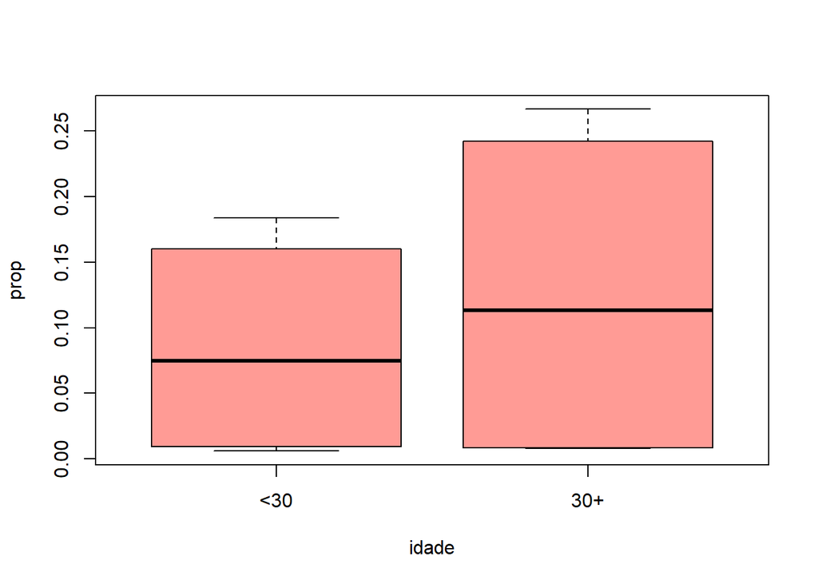

```r
boxplot(prop~idade, col=cores[4])
```

A mediana do número de crianças que não sobreviveram das gestantes fumantes com idade maior que 30 parece maior do que das gestantes com menos idade.

**Código**

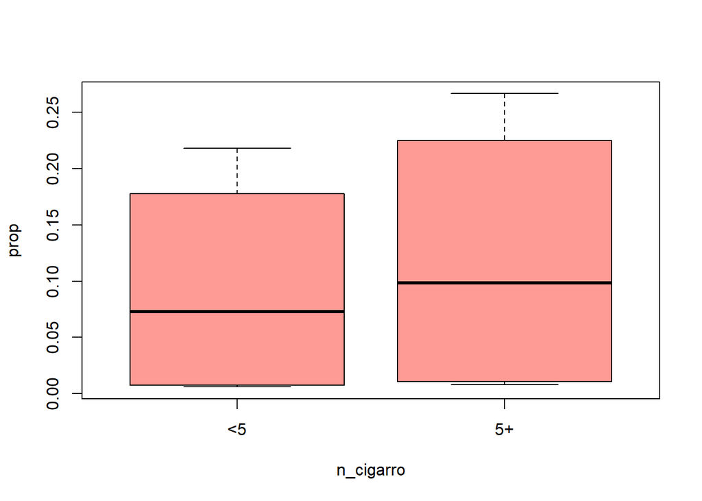

```r
boxplot(prop~n_cigarro, col=cores[4])
```

Temos algum indício de que o consumo maior de cigarros aumenta as chances de não sobrevivência da criança.

**Código**

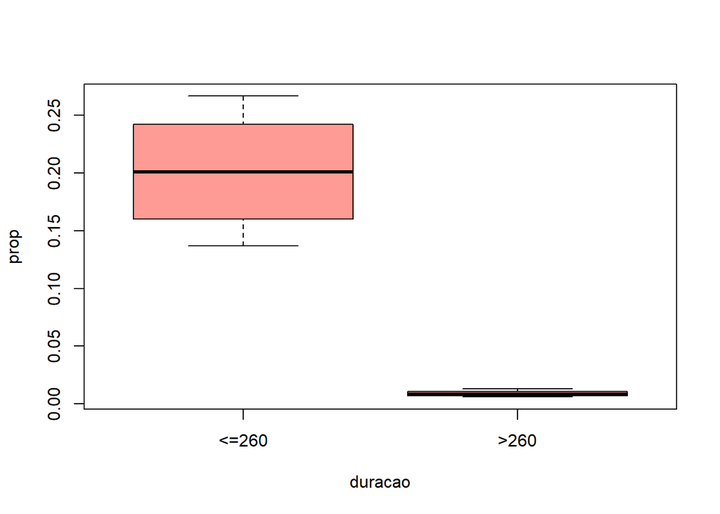

```r
boxplot(prop~duracao, col=cores[4])
```

É bem claro que a mediana da proporção de crianças não sobreviventes é maior com a duração da gestação menor que 260.

## Seleção

**Código**

```
[1] "Binomial-Link(logit)"
```

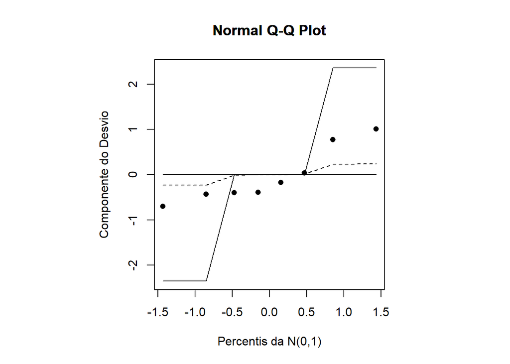

```
[1] "Binomial-Link(cauchit)"
```

```
[1] "Binomial-Link(probit)"
```

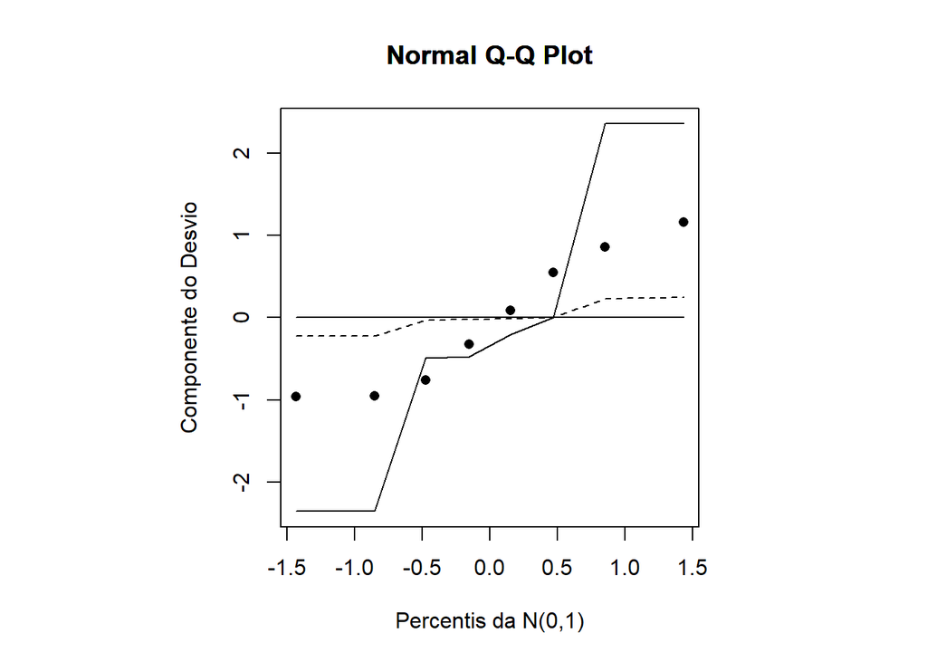

```
[1] "Binomial-Link(cloglog)"
```

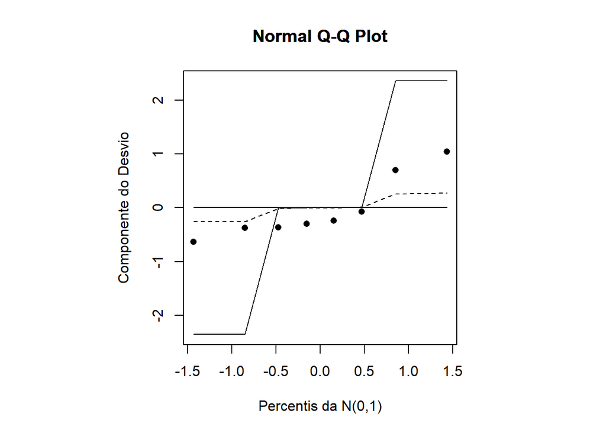

```r
n<-nrow(gestantes)
modelo<-cbind(morte, sobrev) ~ idade + duracao + n_cigarro + idade:duracao + idade:n_cigarro + n_cigarro:duracao

binom<-rbind(
ResultadosBinom(gestantes, modelo, ligacao = "logit", tipo ="envel_bino_logit"),
ResultadosBinom(gestantes, modelo, ligacao = "cauchit", tipo ="envel_bino_cauchit"),
ResultadosBinom(gestantes, modelo, ligacao = "probit", tipo ="envel_bino_probit"),
ResultadosBinom(gestantes, modelo, ligacao = "cloglog", tipo ="envel_bino_cloglog")
)
```

**Código**

```
[1] "Binomial-Link(logit)"
```

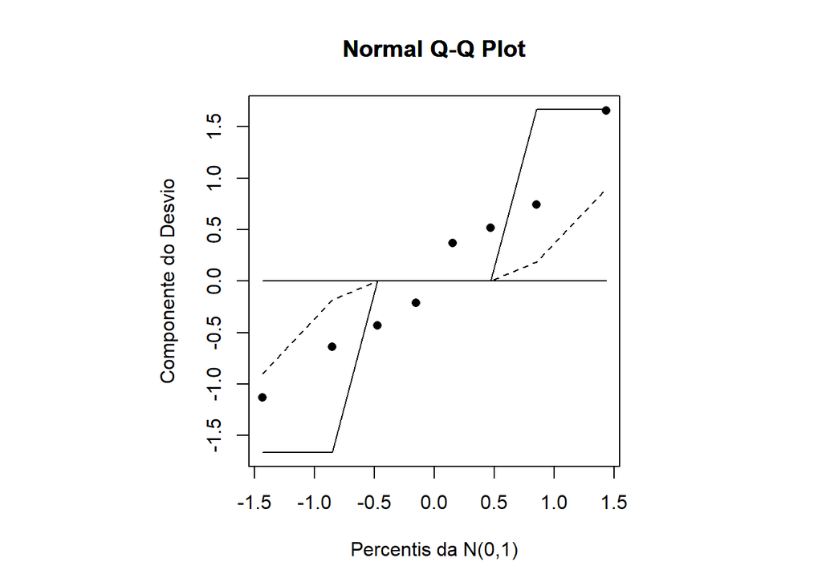

```
[1] "Binomial-Link(cauchit)"
```

```
[1] "Binomial-Link(probit)"
```

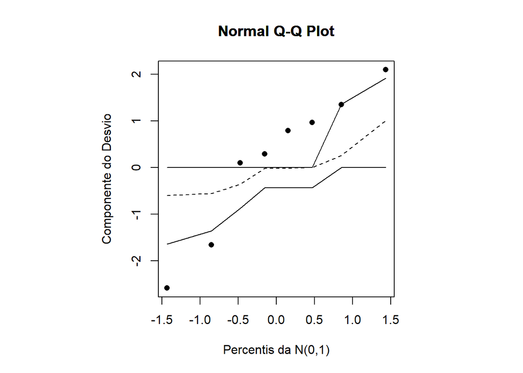

```
[1] "Binomial-Link(cloglog)"
```

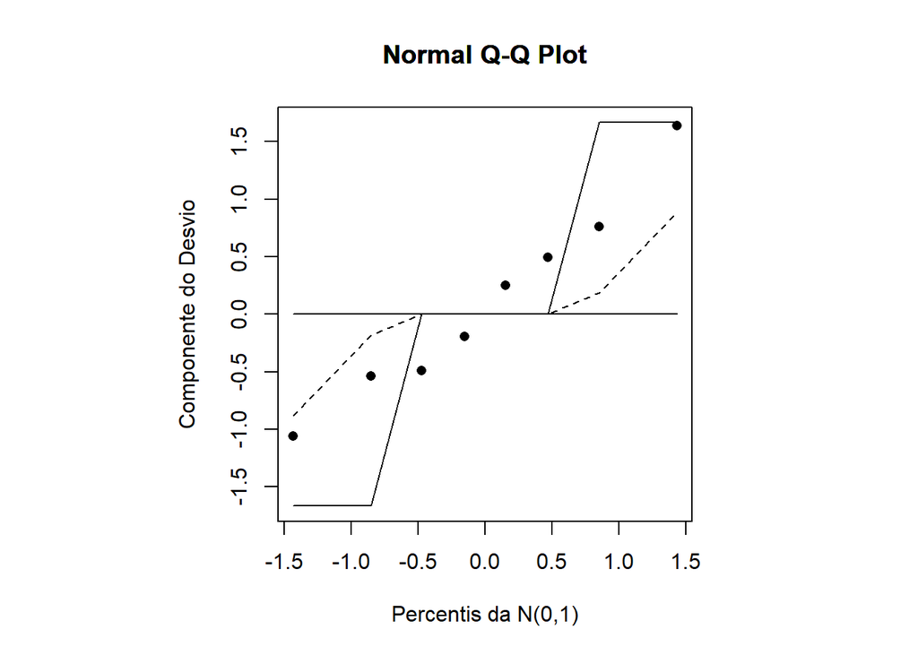

```r
binom2<-rbind(
ResultadosBinom(gestantes, modelo, ligacao = "logit", tipo ="envel_bino_logit",step="JAQ"),
ResultadosBinom(gestantes, modelo, ligacao = "cauchit", tipo ="envel_bino_cauchit",step="JAQ"),
ResultadosBinom(gestantes, modelo, ligacao = "probit", tipo ="envel_bino_probit",step="JAQ"),
ResultadosBinom(gestantes, modelo, ligacao = "cloglog", tipo ="envel_bino_cloglog",step="JAQ")
)
```

**Código**

```r
binom |>
  arrange(BIC, desc=T) |>
  knitr::kable(caption = "Melhor modelo - stepAIC", format ="pipe")
```

Melhor modelo - stepAIC

| Family | QQplot | BIC | Modelo |
| --- | --- | --- | --- |
| Binomial-Link(cloglog) | Ruim | 42.61102 | cbind(morte, sobrev) ~ idade + duracao + n_cigarro |
| Binomial-Link(logit) | Ruim | 42.66549 | cbind(morte, sobrev) ~ idade + duracao + n_cigarro |
| Binomial-Link(cauchit) | Não Rodou | 43.05121 | cbind(morte, sobrev) ~ idade + duracao |
| Binomial-Link(probit) | Ruim | 43.38135 | cbind(morte, sobrev) ~ idade + duracao + n_cigarro |

**Código**

```r
binom2 |>
  arrange(BIC, desc=T) |>
  knitr::kable(caption = "Melhor modelo - stepJAQ", format ="pipe")
```

Melhor modelo - stepJAQ

| Family | QQplot | BIC | Modelo |
| --- | --- | --- | --- |
| Binomial-Link(cloglog) | Ruim | 42.85415 | cbind(morte, sobrev) ~ idade + duracao |
| Binomial-Link(logit) | Ruim | 42.99698 | cbind(morte, sobrev) ~ idade + duracao |
| Binomial-Link(cauchit) | Não Rodou | 43.05121 | cbind(morte, sobrev) ~ idade + duracao |
| Binomial-Link(probit) | Ruim | 46.95586 | cbind(morte, sobrev) ~ duracao |

O modelo selecionado foi o com a ligação logit, pouca diferença no BIC.

## Teste de adequação da função de ligação

**Código**

```r
modelo<-cbind(morte, sobrev) ~ idade + duracao + n_cigarro
fit.model <- glm(modelo  , family=binomial(link=logit))
pl2 <- predict(fit.model)^2
fit.model2<-glm(update.formula(modelo,~ . + pl2), family=binomial(link=logit))
testef(fit.model,fit.model2) # fit.model(H0: pl2 não significativa) #H1: pl2 é significativa
```

```
$f
[1] 0.1756451

$df1
[1] 1

$df2
[1] 3

$pvalue
[1] 0.7033421
```

## Resíduos e Diagnóstico

**Código**

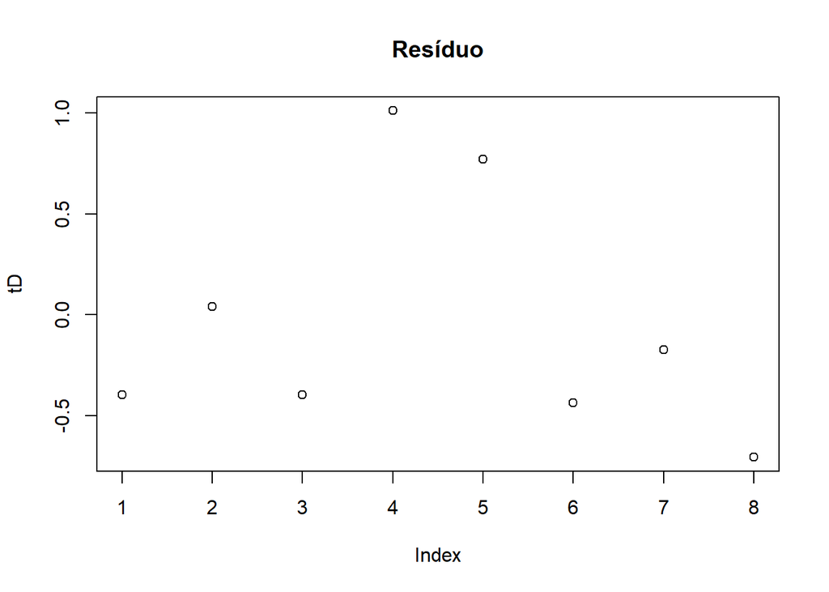

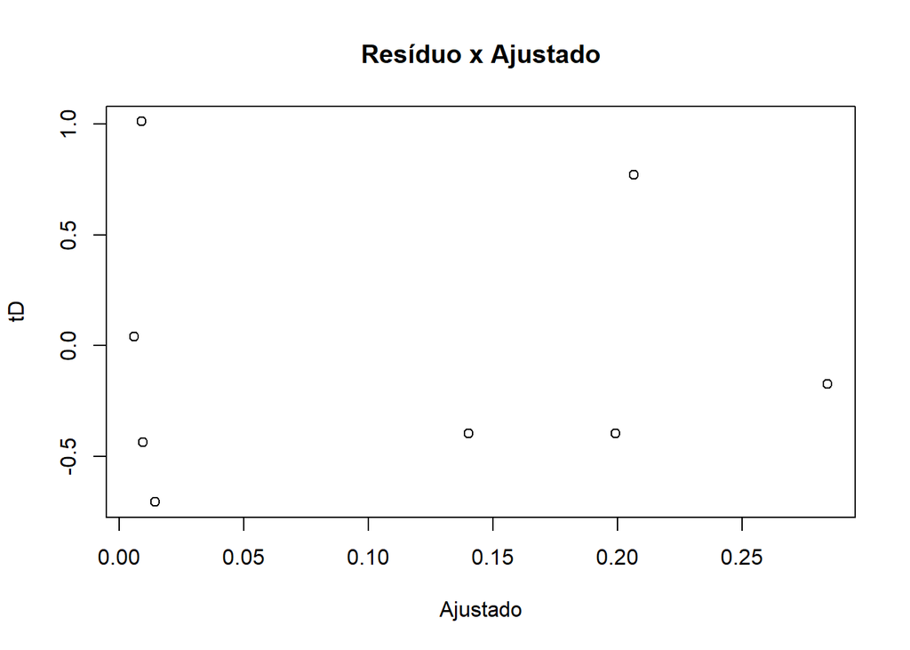

```r
modelo<-cbind(morte, sobrev) ~ idade + duracao + n_cigarro
fit.model <- glm(modelo,family=binomial(link="logit"))
resul.resd<-residuos(fit.model)
```

Não parece ter nenhum padrão nos resíduos, modelo validado.

**Código**

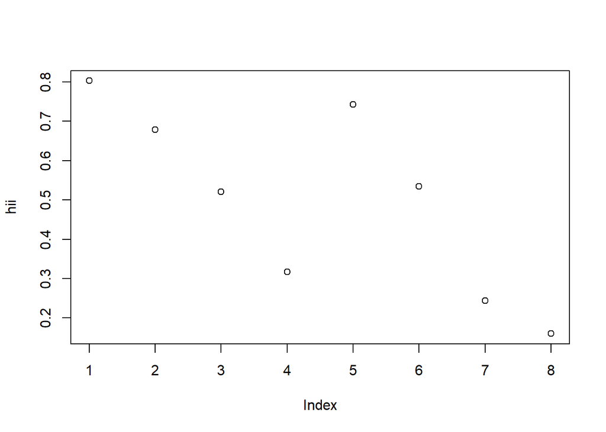

```r
plot(resul.resd$hii, ylab="hii")
```

Não há pontos de alavanca.

**Código**

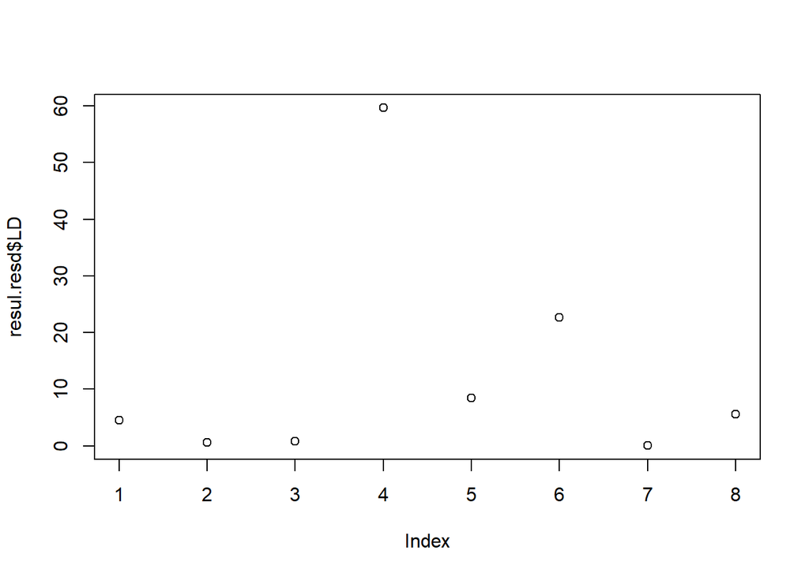

```r
plot(resul.resd$LD)
```

**Código**

```r
gestantes[4,]
```

```
# A tibble: 1 × 6
  idade n_cigarro duracao morte sobrev   prop
  <fct> <fct>     <fct>   <dbl>  <dbl>  <dbl>
1 <30   5+        >260        6    459 0.0129
```

**Código**

```r
summary(prop.mortos)
```

[output not shown]

## Interpretação

**Código**

```r
modelo<-cbind(morte, sobrev) ~ idade + duracao + n_cigarro
fit.model <- glm(modelo,family=binomial(link="logit"))

exp(coef(fit.model))
```

```
(Intercept)    idade30+ duracao>260 n_cigarro5+
  0.1630172   1.5959473   0.0365252   1.5262031
```

- A chance da criança não sobreviver se a idade da gestante fumante for maior que 30 anos aumenta em aproximadamente 60% da chance de não sobreviver quando a gestante tem menos idade.
- A chance da criança morrer dado que a duração da gestação é maior que 260 reduz em 96% da chance quando a gestação tem duração menor.
- A chance da criança não sobreviver quando a gestante fuma mais de 5 cigarros por dia aumenta em 52.6% da chance quando ela fuma menos.

# 23.

**Código**

```r
suppressMessages( dengue <- read_table("dados/lista3/dengue.txt",
                                       col_names = FALSE,
                                       col_types = cols(X5 = col_skip())))
colnames(dengue)<-c("idade","nivel","setor","caso")
dengue$nivel<-as.factor(dengue$nivel)
dengue$setor<-as.factor(dengue$setor)
dengue$caso<-as.factor(dengue$caso)
```

## Análise Exploratória

**Código**

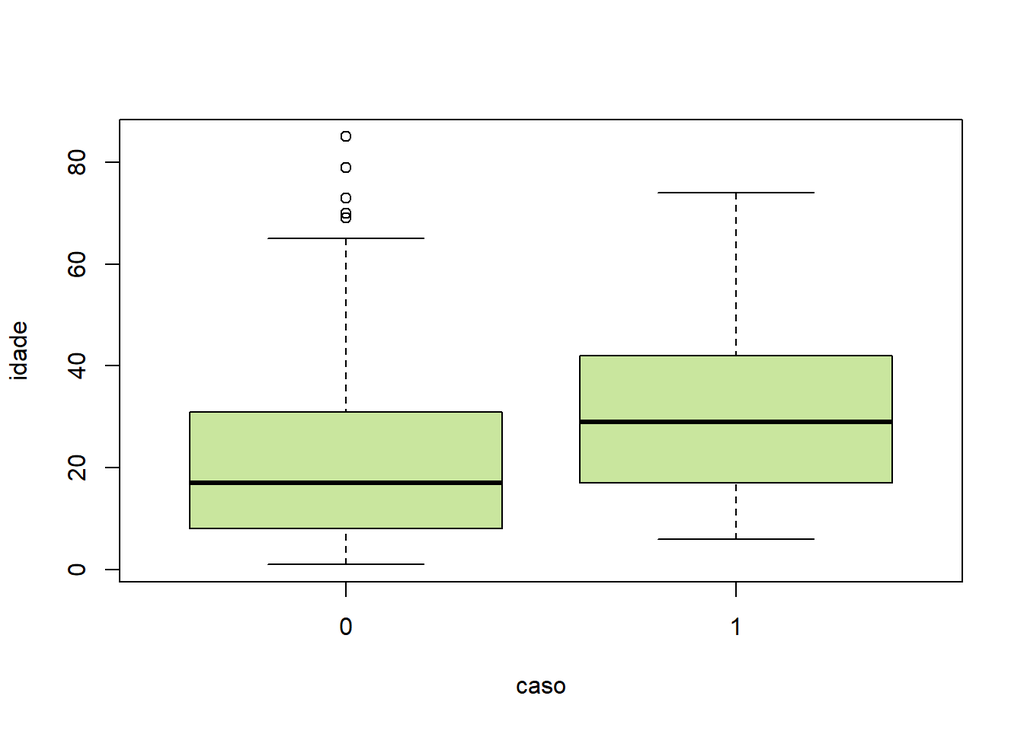

```r
suppressMessages(attach(dengue))
boxplot(idade~caso, col=cores[2])
```

Aparentemente a idade das pessoas com dengue é um pouco maior.

**Código**

```r
tabela<-table(nivel, caso)
prop_caso_nivel <- prop.table(tabela, margin = 1)
prop_caso_nivel
```

```
     caso
nivel         0         1
    1 0.6883117 0.3116883
    2 0.7142857 0.2857143
    3 0.7285714 0.2714286
```

**Código**

```r
tabela<-table(setor, caso)
prop_caso_setor <- prop.table(tabela, margin = 1)
prop_caso_setor
```

```
     caso
setor         0         1
    1 0.8119658 0.1880342
    2 0.5569620 0.4430380
```

O setor 2 da cidade pode ser um local com maior risco de dengue, a proporção de casos é parece ser maior.

## Seleção

**Código**

```
[1] "Binomial-Link(logit)"
```

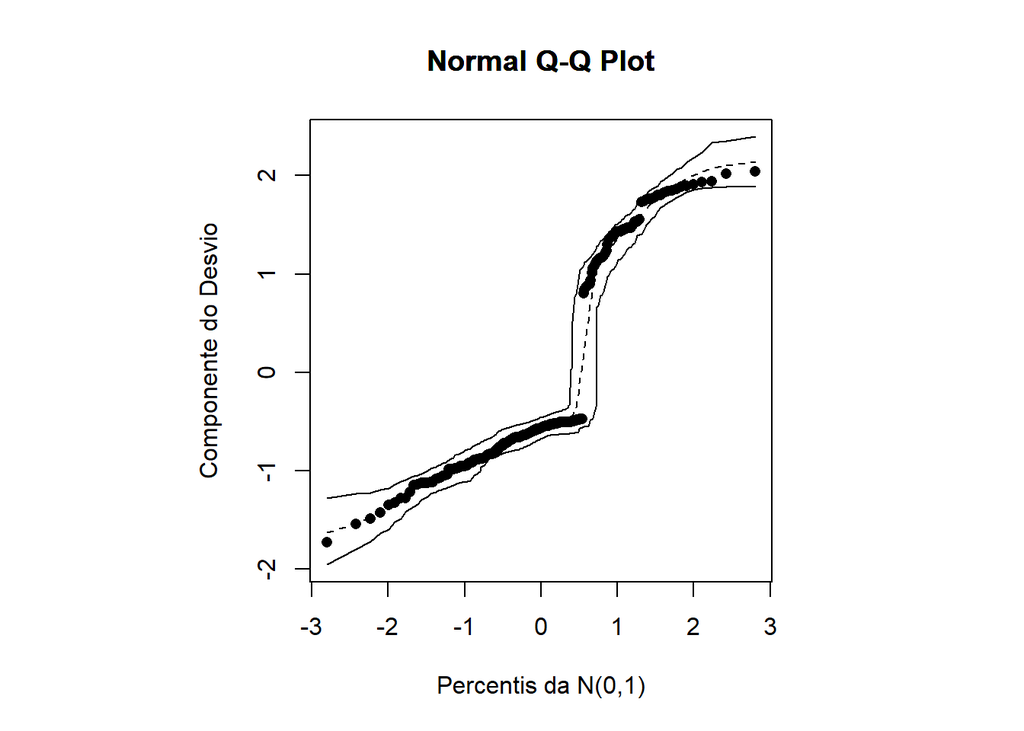

```
[1] "Binomial-Link(cauchit)"
```

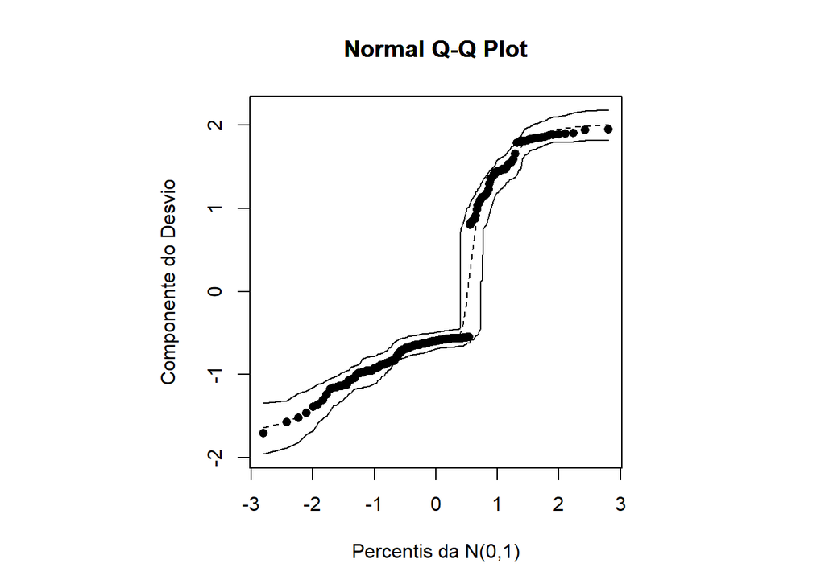

```
[1] "Binomial-Link(probit)"
```

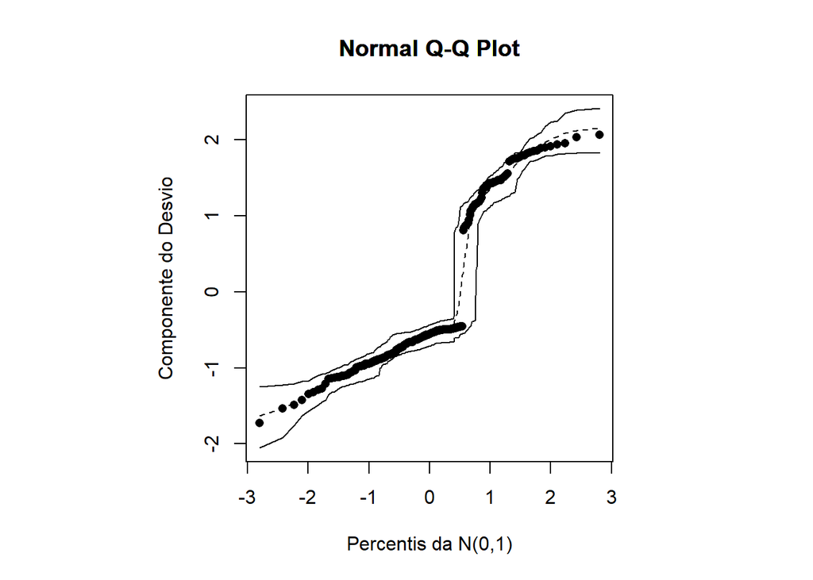

```
[1] "Binomial-Link(cloglog)"
```

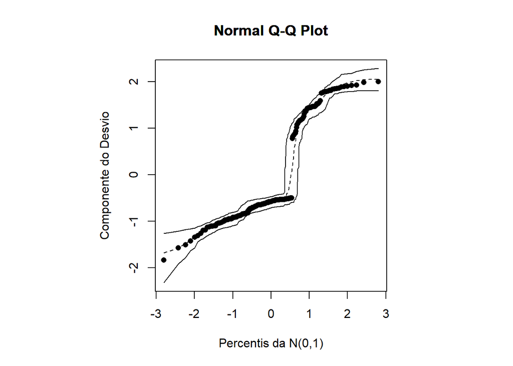

```r
n<-nrow(dengue)
modelo<-caso ~ idade + nivel + setor + idade:nivel + idade:setor + nivel:setor


binom<-rbind(
ResultadosBinom(dengue, modelo, ligacao = "logit", tipo ="envel_bino_logit"),
ResultadosBinom(dengue, modelo, ligacao = "cauchit", tipo ="envel_bino_cauchit"),
ResultadosBinom(dengue, modelo, ligacao = "probit", tipo ="envel_bino_probit"),
ResultadosBinom(dengue, modelo, ligacao = "cloglog", tipo ="envel_bino_cloglog")
)
```

**Código**

```
[1] "Binomial-Link(logit)"
```

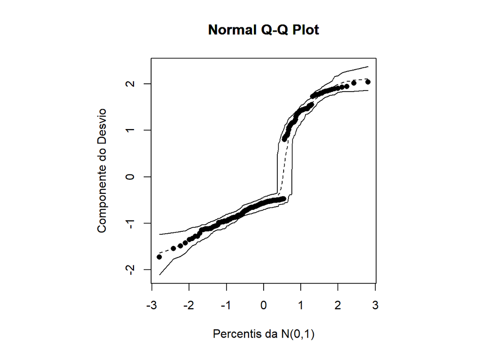

```
[1] "Binomial-Link(cauchit)"
```

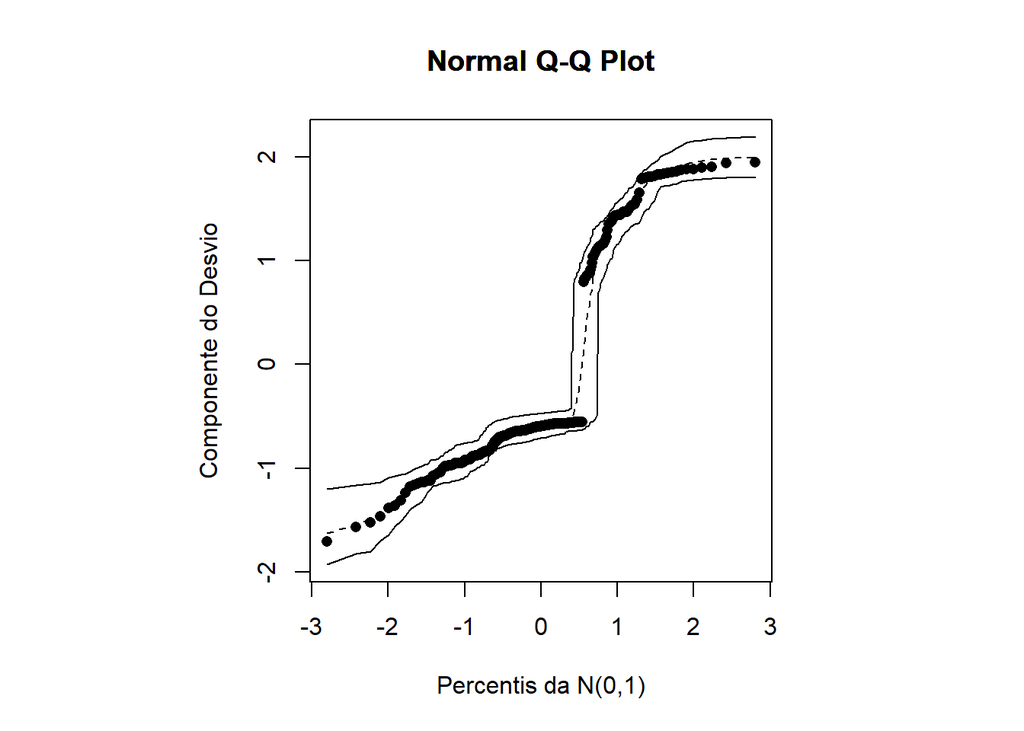

```
[1] "Binomial-Link(probit)"
```

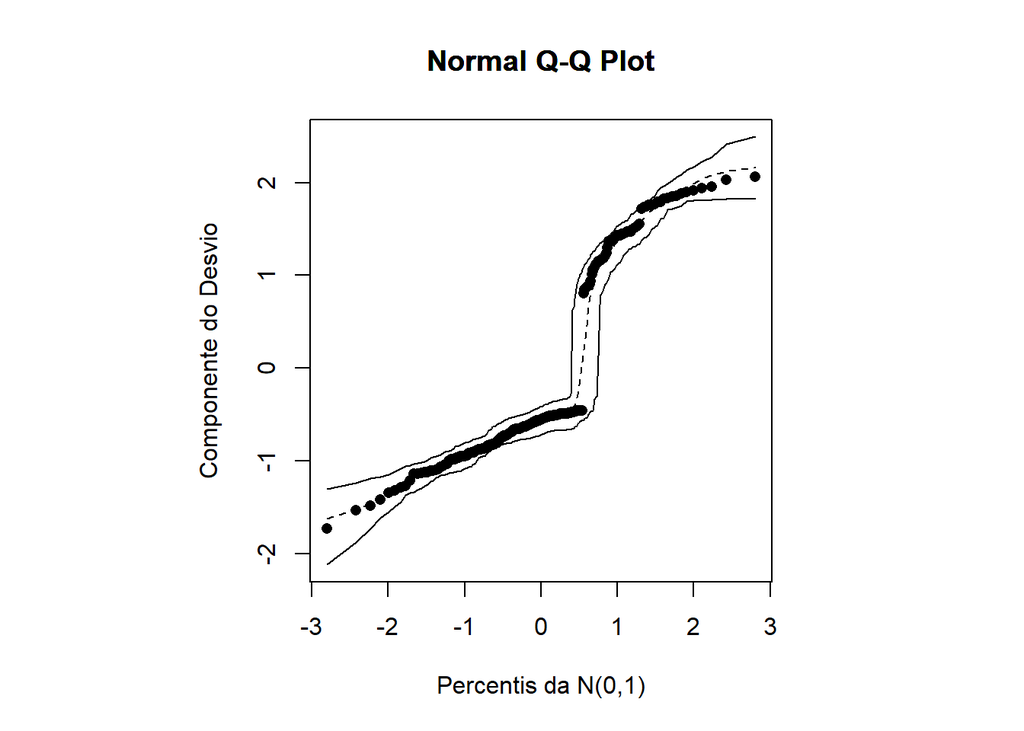

```
[1] "Binomial-Link(cloglog)"
```

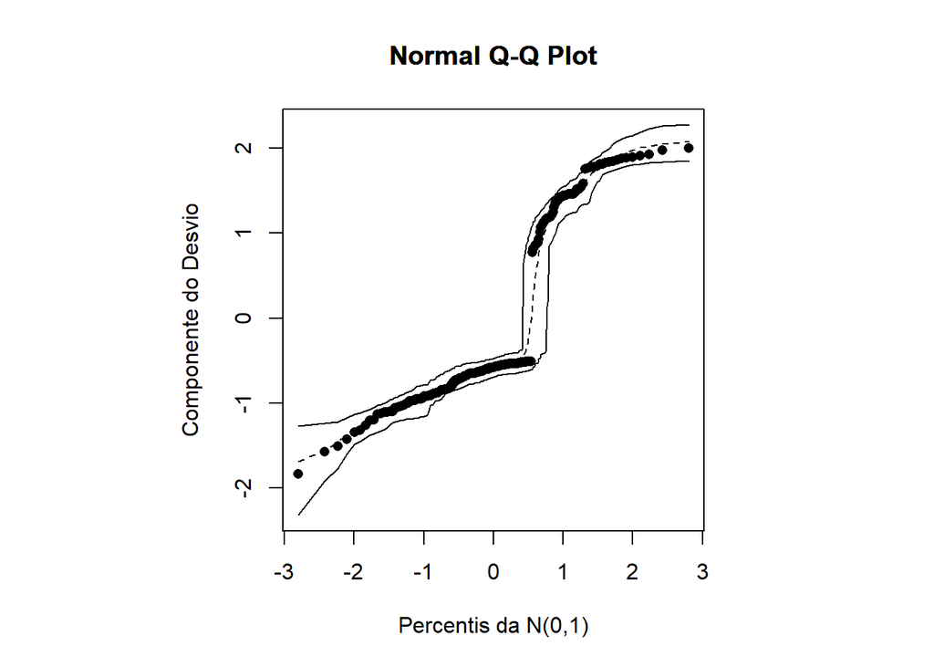

```r
binom2<-rbind(
ResultadosBinom(dengue, modelo, ligacao = "logit", tipo ="envel_bino_logit",step="JAQ"),
ResultadosBinom(dengue, modelo, ligacao = "cauchit", tipo ="envel_bino_cauchit",step="JAQ"),
ResultadosBinom(dengue, modelo, ligacao = "probit", tipo ="envel_bino_probit",step="JAQ"),
ResultadosBinom(dengue, modelo, ligacao = "cloglog", tipo ="envel_bino_cloglog",step="JAQ")
)
```

**Código**

```r
binom |>
  arrange(BIC, desc=T) |>
  knitr::kable(caption = "Melhor modelo - stepAIC", format ="pipe")
```

Melhor modelo - stepAIC

| Family | QQplot | BIC | Modelo |
| --- | --- | --- | --- |
| Binomial-Link(probit) | Ótimo | 227.1744 | caso ~ idade + setor |
| Binomial-Link(logit) | Ótimo | 227.4736 | caso ~ idade + setor |
| Binomial-Link(cloglog) | Ótimo | 227.9448 | caso ~ idade + setor |
| Binomial-Link(cauchit) | Ótimo | 228.5885 | caso ~ idade + setor |

**Código**

```r
binom2 |>
  arrange(BIC, desc=T) |>
  knitr::kable(caption = "Melhor modelo - stepJAQ", format ="pipe")
```

Melhor modelo - stepJAQ

| Family | QQplot | BIC | Modelo |
| --- | --- | --- | --- |
| Binomial-Link(probit) | Bom | 227.1744 | caso ~ idade + setor |
| Binomial-Link(logit) | Ótimo | 227.4736 | caso ~ idade + setor |
| Binomial-Link(cloglog) | Ótimo | 227.9448 | caso ~ idade + setor |
| Binomial-Link(cauchit) | Ótimo | 228.5885 | caso ~ idade + setor |

O modelo selecionado foi caso ~ idade + setor com a ligação **logit**.

## Teste de adequação da função de ligação

**Código**

```r
modelo<-caso ~ idade + setor
fit.model <- glm(modelo  , family=binomial(link=logit))
pl2 <- predict(fit.model)^2
fit.model2<-glm(update.formula(modelo,~ . + pl2), family=binomial(link=logit))
testef(fit.model,fit.model2) # fit.model(H0: pl2 não significativa) #H1: pl2 é significativa
```

```
$f
[1] 0.5808106

$df1
[1] 1

$df2
[1] 192

$pvalue
[1] 0.44693
```

A função de ligação é adequada.

## Resíduos e diagnóstico

**Código**

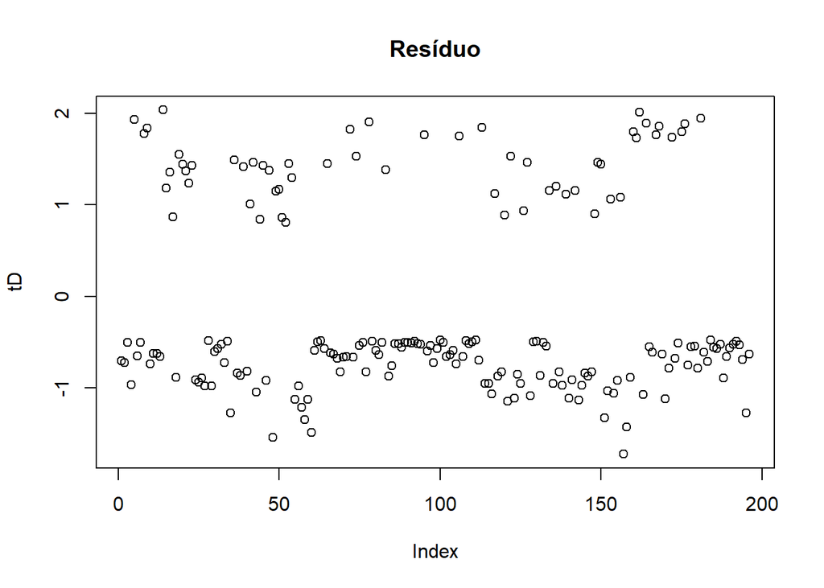

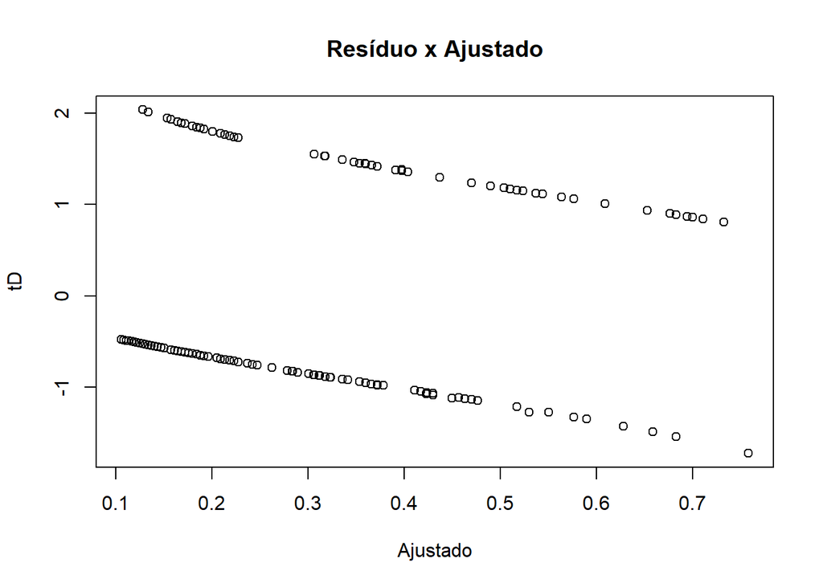

```r
modelo<-caso ~ idade + setor
fit.model <- glm(modelo,family=binomial(link="logit"))
resul.resd<-residuos(fit.model)
```

**Código**

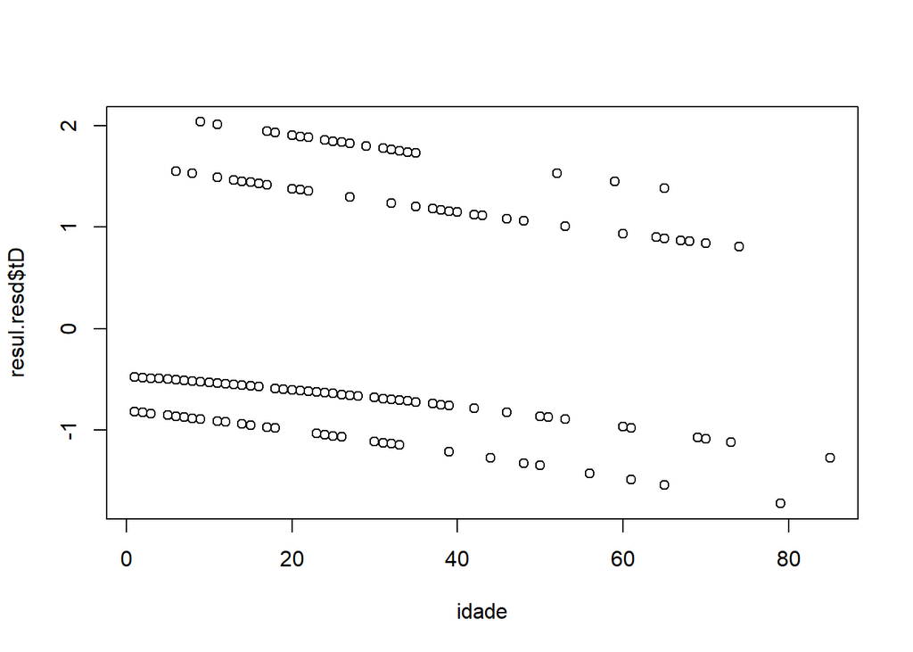

```r
plot(resul.resd$tD~idade)
```

O modelo não foi validado, os resíduos. Porém, vamos dar sequência com a análise de diagnóstico e interpretação do modelo.

**Código**

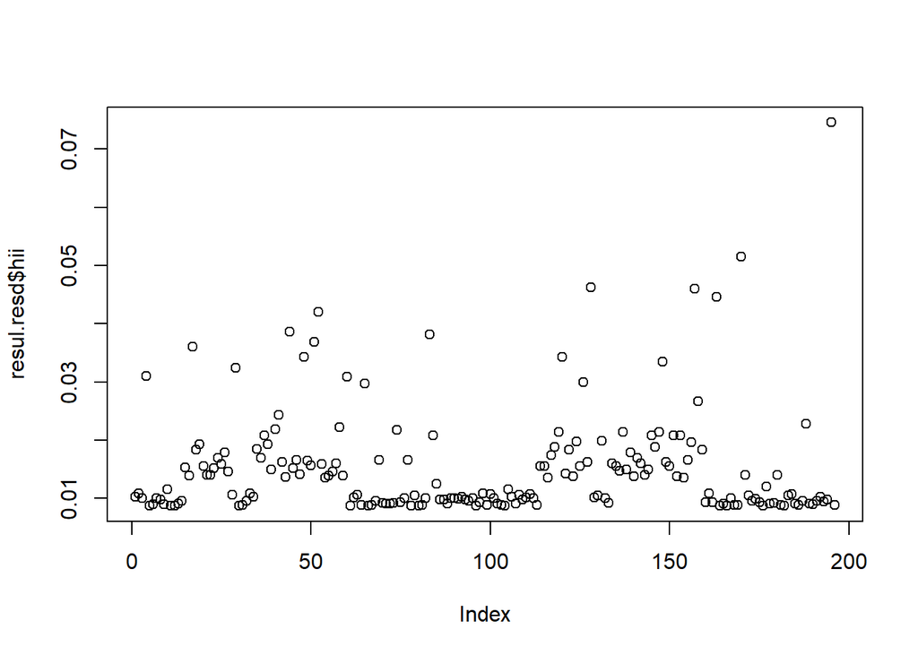

```r
plot(resul.resd$hii)
```

**Código**

```r
dengue[196,]
```

```
# A tibble: 1 × 4
  idade nivel setor caso
  <dbl> <fct> <fct> <fct>
1    24 2     1     0
```

**Código**

```r
summary(idade)
```

```
   Min. 1st Qu.  Median    Mean 3rd Qu.    Max.
   1.00   10.75   21.00   25.18   35.00   85.00
```

A observação 196 é a com maior alavanca, ela possui uma idade que está perto da média e mora no setor 1 da cidade.

**Código**

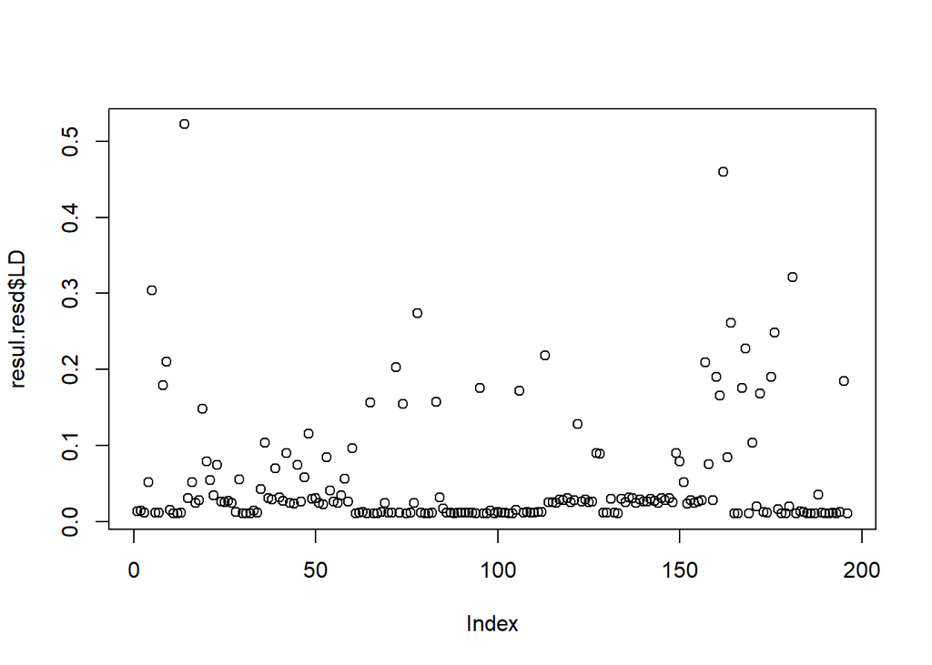

```r
plot(resul.resd$LD)
```

**Código**

```r
dengue[c(14,162),]
```

```
# A tibble: 2 × 4
  idade nivel setor caso
  <dbl> <fct> <fct> <fct>
1     9 1     1     1
2    11 3     1     1
```

**Código**

```r
summary(idade)
```

```
   Min. 1st Qu.  Median    Mean 3rd Qu.    Max.
   1.00   10.75   21.00   25.18   35.00   85.00
```

## Interpretação

**Código**

```r
exp(coef(fit.model))
```

```
(Intercept)       idade      setor2
  0.1153644   1.0271756   3.2598900
```

- Como suspeitado pela análise exploratória uma pessoa moradora do setor 2 da cidade apresenta uma razão chances 3.26 vezes maior de ter caso de dengue que uma moradora do setor 1.
- Para o incremento de uma unidade na idade a razão de chances de ter dengue aumenta em aproximadamente 3%.

# 25.

**Código**

```r
suppressMessages(pulso <- read_table("dados/lista3/pulso.txt",
    col_names = FALSE))
colnames(pulso)<-c("pulsacao","fuma","peso")
pulso$pulsacao<-as.factor(pulso$pulsacao)
pulso$fuma<-as.factor(pulso$fuma)
```

## Análise Exploratória

**Código**

```r
suppressMessages(attach(pulso))

prop.table(table(fuma,pulsacao), margin=1)
```

```
    pulsacao
fuma         1         2
   1 0.6428571 0.3571429
   2 0.8125000 0.1875000
```

**Código**

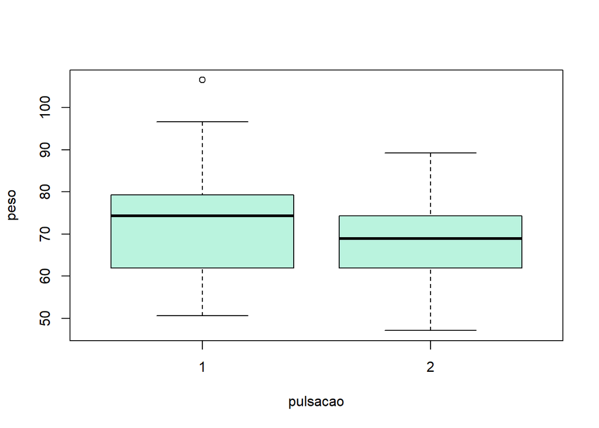

```r
boxplot(peso~pulsacao, col=cores[1])
```

## Seleção

**Código**

```
[1] "Binomial-Link(logit)"
```

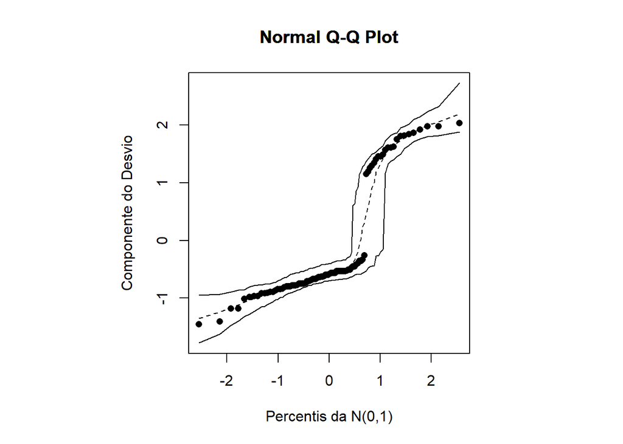

```
[1] "Binomial-Link(cauchit)"
```

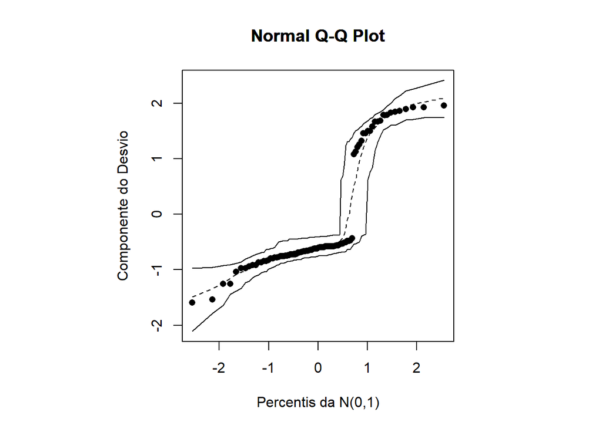

```
[1] "Binomial-Link(probit)"
```

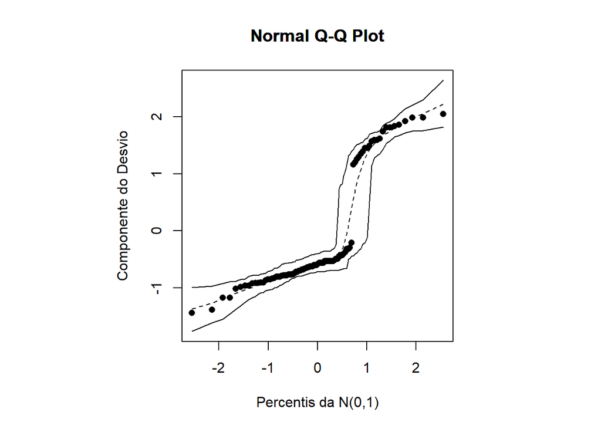

```
[1] "Binomial-Link(cloglog)"
```

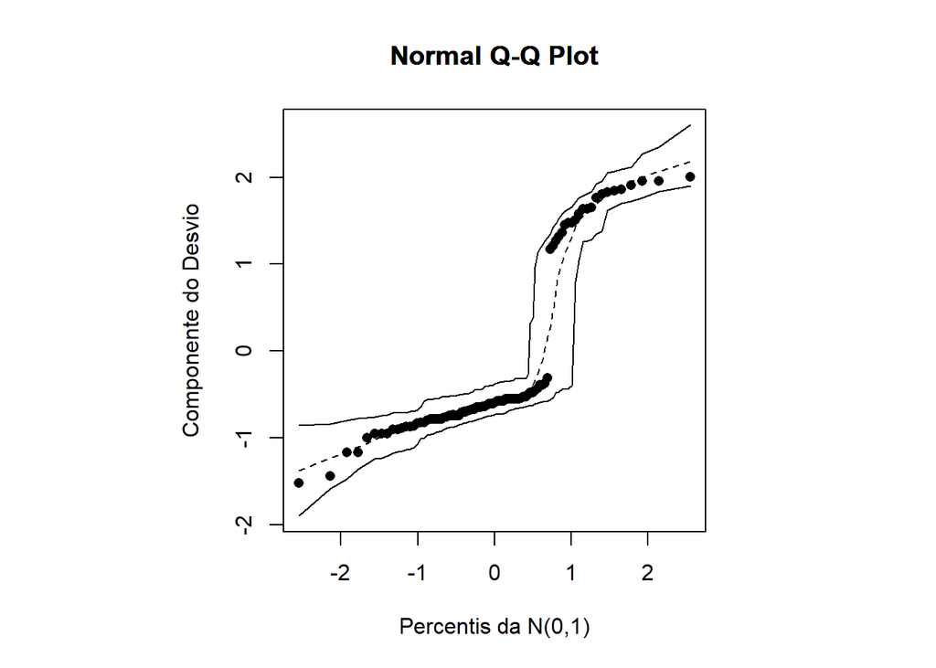

```r
n<-nrow(pulso)
modelo<-pulsacao~peso+fuma+peso:fuma

binom<-rbind(
ResultadosBinom(pulso, modelo, ligacao = "logit", tipo ="envel_bino_logit"),
ResultadosBinom(pulso, modelo, ligacao = "cauchit", tipo ="envel_bino_cauchit"),
ResultadosBinom(pulso, modelo, ligacao = "probit", tipo ="envel_bino_probit"),
ResultadosBinom(pulso, modelo, ligacao = "cloglog", tipo ="envel_bino_cloglog")
)
```

**Código**

```r
binom |>
  arrange(BIC, desc=T) |>
  knitr::kable(caption = "Melhor modelo - stepAIC", format ="pipe")
```

Melhor modelo - stepAIC

| Family | QQplot | BIC | Modelo |
| --- | --- | --- | --- |
| Binomial-Link(probit) | Ótimo | 107.0333 | pulsacao ~ peso + fuma |
| Binomial-Link(logit) | Ótimo | 107.2049 | pulsacao ~ peso + fuma |
| Binomial-Link(cloglog) | Ótimo | 107.5166 | pulsacao ~ peso + fuma |
| Binomial-Link(cauchit) | Ótimo | 108.0765 | pulsacao ~ peso + fuma |

Vamos escolher o modelo com ligação **logit**.

## Teste de adequação da função de ligação

**Código**

```r
modelo<-pulsacao ~ peso + fuma
fit.model <- glm(modelo  , family=binomial(link=logit))
pl2 <- predict(fit.model)^2
fit.model2<-glm(update.formula(modelo,~ . + pl2), family=binomial(link=logit))
testef(fit.model,fit.model2) # fit.model(H0: pl2 não significativa) #H1: pl2 é significativa
```

```
$f
[1] 0.7627341

$df1
[1] 1

$df2
[1] 88

$pvalue
[1] 0.3848512
```

Não temos evidências para rejeitar a hipótese nula, ou seja, a função de ligação logit é adequada.

## Resíduos e diagnóstico

**Código**

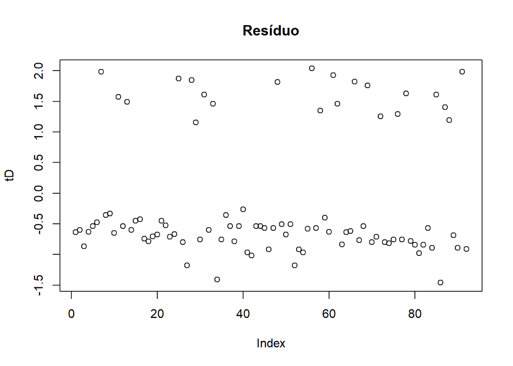

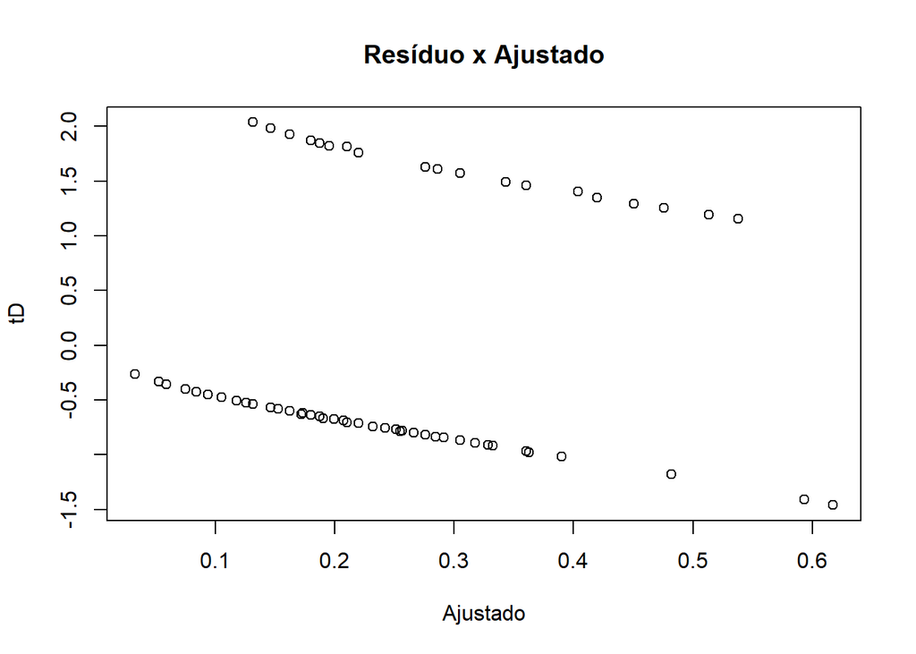

```r
modelo<-pulsacao ~ peso + fuma
fit.model <- glm(modelo,family=binomial(link="logit"))
resul.resd<-residuos(fit.model)
```

**Código**

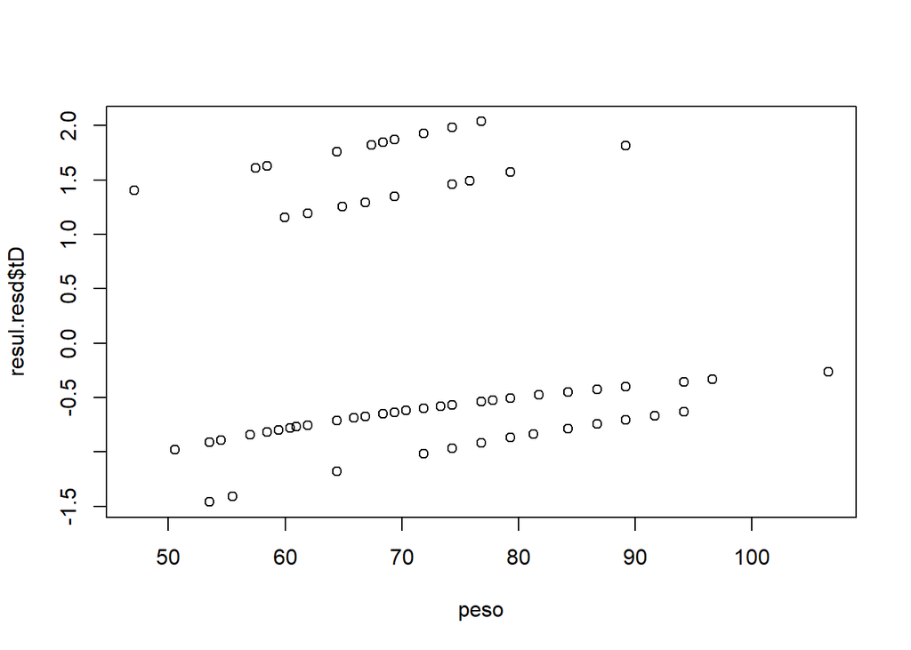

```r
plot(resul.resd$tD~peso)
```

Os resíduos não estão bem comportados, o modelo não foi validado.